# Family Factors

Dr. Carr

Wednesday, September 03, 2014

```
                  Designs for Two Factors
```

```
By        Daniel B. Carr
          First draft September 21, 2013
          Last revised Aug 25, 2014

Article  Brigid Schulte, 2013.
         "Recession had further polarized families"
         Washington Post, Sept. 11, 2013.

Document  Qian, Zhenchao. Sept. 2013
         "Divergent Paths of American Families"
          Department of Sociology at Ohio State University
          The class folder has a PDF file from the web.
          Newpapers article focused on Table 7 and
          combined some family types
```

The plot represents 24 percents. We can thinks of these as forming a 2-way table indexed by race with four categorical values and family type with 6 categorical values. In this class we usually refer to such categorical variables as factors there values as level of the factor. An example of a family type is “Married, both working”.  
The family type percents are percent of the total for each race. The percent totals for each race turn out to be 99 or 101 due to rounding to integers. The values in Table 7 of the source were rounded. They will work well enough for our redesign purposes.

It is nice to see a two factor plot in the Washington Post. For each race the Post graph design use 6 “bubbles” arranged in a circle to show the family type percents. Their design shows the 24 values in the bubbles. This serves as both spread out table of numbers and a plot. While the original example may have higher entertainment appeal, it is not as convenient as a table of numbers for reading and comparing numbers. Our plots will be better than their plot after revealing patterns and more direct leveling of values.

Below We use dot and bar plots that have higher perceptual accuracy of extraction than bubble areas. We rearrange races and family types to simply the appearance an bring out patterns. We use more direct labeling than linking the 6 family types names to symbols using 2 shades of 3 colors.  
It is not so easy to keep 6 color and label pairs in mind.

We go a little further with some designs by showing reference values. It is often easier to compare several values to a single reference value than all pairs of values to each other.

We could take the next step and explicitly show the differences from the reference values for example using arrow.

We take the controversial step of creating small perceptual group by connect points with lines to provide local focus and support make comparison across distances that invovle eye saccades.  
I conjecture that the simple shape. See  
the article by Carr and Sun in the folder.

``` Sections

1. Entering data
2. Dot plots with lines the origin The second reorders row and columns to match Washington Post order
3. Simplifying appearance to help reveal patterns 3.1 Reordering rows 3.2 Reordering columns to change panel order 3.3 Comments on perceptual group to further simply appearance 3.4 More comments on sorting and apppearance
4. Race comparisons for each family type
5. Barcharts instead of dot plot
6. Adding a reference values using line
7. Alternative layouts 7.1 A two column layout 7.2 A three column layout
8. Using factors in lattice and gglot2 to produce a four column graph analogous to the Washington Post design 8.1 Some patterns appear  
   8.2 Creating two perceptual groups with three dots 8.3 Appearance comments 8.4 Creating three groups of two
9. Entering Data

When entering data by hand, use a convenient organization. After reading the data into R. Transform the data structure as needed to produce the graph.

I used R’s c()function to create a vector with the 24 values. I entered the 24 values as arguments to c().  
Function arguments are separated by commas.

A systematic approach helps when it comes to correctly labeling the values. When using the graph from the Washington Post I chose to focused locally on each race with its six bubbles arranged in a circle. I went around the circle clockwise and wrote down the six family type percents written in the bubbles. The left most race was white. I wrote the six white family type values in the first line of the R script c() function line as shown below. The next line has six values for black on the second line and so on. R continues to read lines until it encounters the closing parenthesis for a function. The spacing and alignment of numbers accross was for my convenience. R will strip out the white space,

Note many people prefer to enter data in Excel and read such files into R.

The script then restructures the vector dat of length 24 into a matrix with 6 rows and hence 4 rows. By default matrix(data=dat, nrow=6) will use the first 6 elements of vector dat as the row values in the first column, the next 6 elements as the row values of the second columne ans so on for subsequent columns.

The script then creates a vector of simplified names for the family type, a vector of names for the races, and then uses these as row and column names for the matrix mat.

```r
dat<- c(22, 50,  8,  2, 13,  6,
         5, 24, 13, 24, 20, 15,
        21, 33,  9,  7, 20,  9,
        24, 53,  4,  1, 12,  5)

mat <- matrix(data=dat, nrow=6)

type <- c( "Married, Father Working", "Married, Both Working",
           "Divorced Mother","Never-married Mother",
          "Other", "Grandparents")
race <- c("White","Black","Hispanic","Asian")
rownames(mat) <- type
colnames(mat) <- race
mat
```

```
##                         White Black Hispanic Asian
## Married, Father Working    22     5       21    24
## Married, Both Working      50    24       33    53
## Divorced Mother             8    13        9     4
## Never-married Mother        2    24        7     1
## Other                      13    20       20    12
## Grandparents                6    15        9     5
```

2. Dot plots with lines to the origin. The second plot reorders row and columns to match Washington Post order

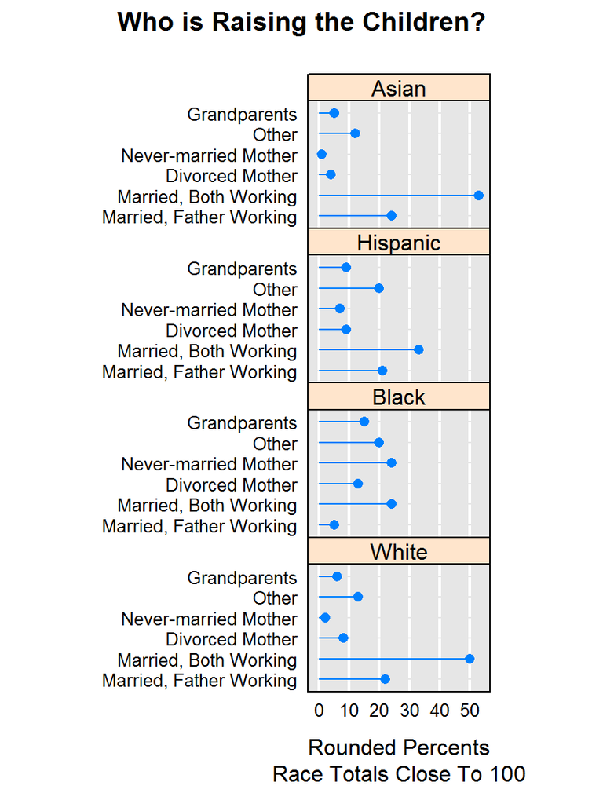

```r
library(lattice)

dotplot(mat,groups=FALSE,
  layout=c(1,4),aspect=.7,
  origin=0,type=c("p","h"),
  main="Who is Raising the Children?",
  xlab="Rounded Percents\nRace Totals Close To 100",
  scales=list(x=list(tck=0, alternating=FALSE)),
  panel=function(...){
    panel.fill(rgb(.9,.9,.9))
    panel.grid(h=0,v=-1,col="white",lwd=2)
    panel.dotplot(col=rgb(0,.5,1),cex=.9,...)
  }
)
```

When the lattice dotplot has a matrix as input, the row names become row labels and the column names become panel labels. R also associates counting integers with the row and column names and uses the number follow the graph convention opposed to a table reading convention. That is, small value appear near the bottom of the y-axis and large values appear near the top.

The result is that Married, Father Working, is row 1 in mat, so plots at the bottom of family type list. Similarly White is column 1 mat and so appears at bottom of the vertical stack of panels.

We can use indices (subscript) to rearrange matrix rows and columns. To more comfortably compare the R plot with the article plot, I chose to reverse the rows and columns using subscripts.

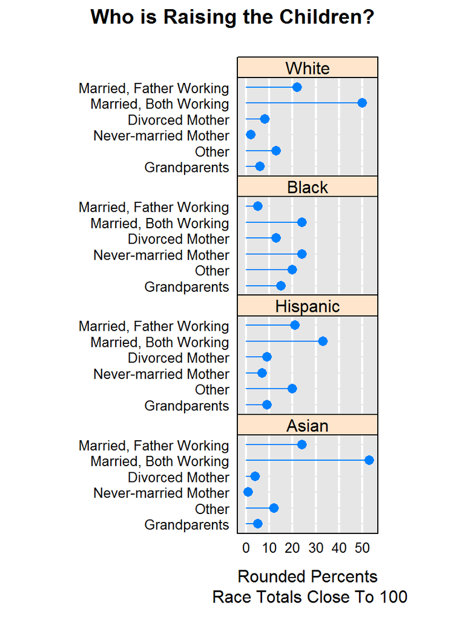

```r
# Save a label to use in plots below
xlab <- "Rounded Percents\n Race Totals Close To 100"

reOrderMat <- mat[6:1,4:1]  # reverse the rows and columns
dotplot( reOrderMat, groups=FALSE,
  layout=c(1,4),aspect=.7,
  origin=0,type=c("p","h"),
  main="Who is Raising the Children?",
  xlab=xlab,
  scales=list(x=list(tck=0, alternating=FALSE)),
  panel=function(...){
    panel.fill(rgb(.9,.9,.9))
    panel.grid(h=0,v=-1,col="white",lwd=2)
    panel.dotplot(col=rgb(0,.5,1),cex=1.1,...)
  }
)
```

We can scan up and down the panels comparing all values against the common scale at the bottom. The grid lines make it easy compare the values against the common scale. We can see two largest percents are White and Asian familty topes of Married, Both Working. The Asian dot is a little to the right 50 percent grid line so we can tell it is larger value than the White dot which is on the grid line. A similar order for White and Asian appears for Married, Father Working.  
The whole pattern of dot for White and Asia appears similar.

3. Simplifying appearance and revealing patterns

Our eyes jump around a lot when we look at plots. However suppose we could look from dot to dot as we work our way down the rows within each panel. Consider the dot to dot traversal lengths that our eyes would follow.  
We could sum the lengths for each panel. I think such sums provide a rough indicator of panel appearance complexity and the sum of the panel sums provides an indicator of plot complexity.

Side note: As an alternate measure that does not depend on the height of the column of panels we could sum the absolute difference in the x coordinates from row to row.

We can simplify appearance by rearranging rows to reduce the complexity indices suggested above! More generally arranging plot elements so similar elements appear close together tends to simplify appearance.

3.1 Reordering the Rows of a Matrix

We can reorder the rows of a matrix to make the values in a Single column to be in increasing or decreasing order. Typically other columns will not also be in increasing or decreasing order.

As a compromise was can compute a value for each row and sort rows to be in increasing or decreasing oder based on thes values.

Here we compute the average of column (race) values for each row.  
In general the data can influence our choice. If there are outliers the median is likely a better choice as Cleveland has suggested.

The task can influence our choice of sorting criterion. We might be particularly interested in comparing the maximum values so use the maximum across the columns as the basis of sorting.

There are more computationally involved computed variables than we can use as a sorting variable. A reasonable choice for multivariate data is often the first principal component because order the rows in the direction of maximum variation.

Some algorithms such as minimal spanning tree breadth traversal provide the ordering directly. Unfortunately the traversal algorithm is in S-Plus but not in R.

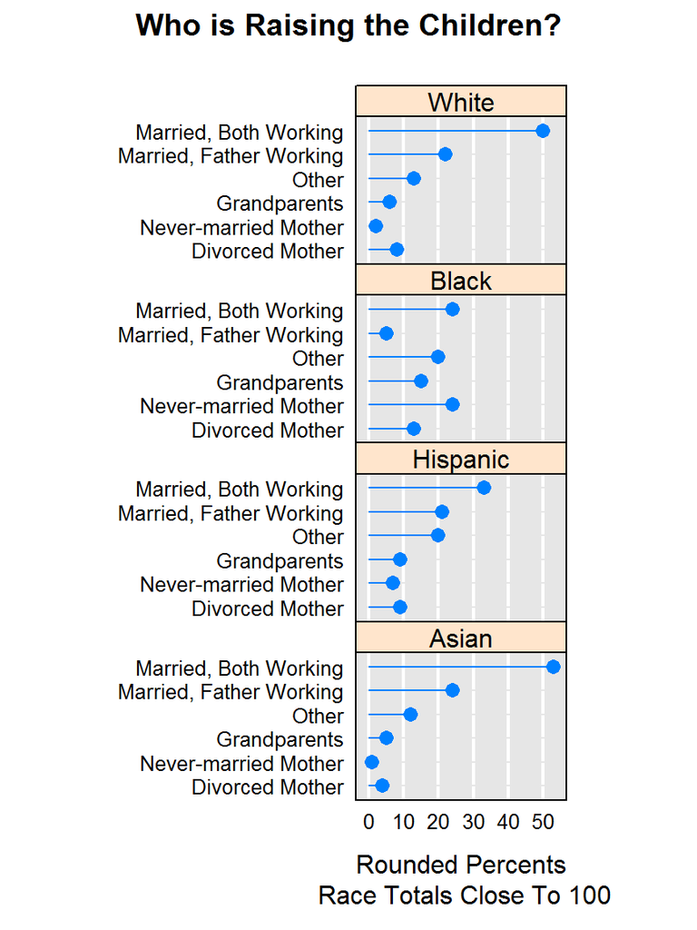

```r
# Sorting based on Row means

means <- rowMeans(mat)  # Find row means is

typeOrder <- order(means)

dotplot(mat[typeOrder,4:1], groups=FALSE,
  layout=c(1,4),aspect=.7,
  origin=0,type=c("p","h"),
  main="Who is Raising the Children?",
  xlab=xlab,
  scales=list(x=list(tck=0, alternating=FALSE)),
  panel=function(...){
    panel.fill(rgb(.9,.9,.9))
    panel.grid(h=0,v=-1,col="white",lwd=2)
    panel.dotplot(col=rgb(0,.5,1),cex=1.1,...)
  }
)
```

Now the Married, Both Working type with which tends to have the largest value across races appear at the top of each panel. The pattern of dots in the panels look much simpler, especially in White and Asian panels.

There are communication settings when a particular order of row can be important that providing simple appearance. Sometimes the the communication goal is to obscure the pattern but not in this class.

3.2 Reordering columns to change panel order

Do not stop redesigning immediately after the first improvement. Consider taking next steps.

A quick glance at the plot suggests we can simplify appearance by putting White and Asian panels (or facets in ggplot2) by each other. Is there a way to compute the panel order? Yes.

As first thought we might consider computing the average across rows of family type values to obtain the sorting variable to use in reordering the columns.

However, without rounding the family type percents would total 100. The averages divide “100” by 6 and so should all be the same.

Another approach uses a powerful tool called multidimensional scaling. Multidimensional scaling (MDS) provide plotting coordinates for cases with multiple variables. When we think a matrix in R in a cases by variables context the row of the matrix are cases and the columns are variables.  
We will use the transpose function t() function to transpose our matrix.

```r
raceCase <- t(mat)
raceCase
```

```
##          Married, Father Working Married, Both Working Divorced Mother
## White                         22                    50               8
## Black                          5                    24              13
## Hispanic                      21                    33               9
## Asian                         24                    53               4
##          Never-married Mother Other Grandparents
## White                       2    13            6
## Black                      24    20           15
## Hispanic                    7    20            9
## Asian                       1    12            5
```

Multidimensional scaling is based on approximating the distance matrix between all pairs of case. The R function to compute distance matrix between is dist(). The variable values need to be in comparable units for this to make sense. Our values are percents so this is okay.

```r
raceDist <- dist(raceCase)
raceDist
```

```
##           White  Black Hispanic
## Black    40.050
## Hispanic 19.339 26.038
## Asian     5.657 44.452   23.452
```

The lower triangle of the distance matrix shown in the R Console suffices since the matrix is symmetric and the diagonal is 0. Reading rows can see there is a big distance between Black and White but the biggest distance is between Asian and Black.

Side note:_________________________

Computing the euclidean distance for Black and White

If there were only two variables this computation would be like computing the hypotenuse length of a right triangle. the difference the two variable for Black and White would have two values. The length of one side of the triangle would be the absolute value of the difference for the first variable. The length for the second side of the triangle would be the absolute value of the difference for the second value. Here we have six differences that we square, sum and then take the square root get a distance (or length).

```r
# Compute the Euclidean distance between White and Black

mat
```

```
##                         White Black Hispanic Asian
## Married, Father Working    22     5       21    24
## Married, Both Working      50    24       33    53
## Divorced Mother             8    13        9     4
## Never-married Mother        2    24        7     1
## Other                      13    20       20    12
## Grandparents                6    15        9     5
```

```r
WBdif <- mat[,"White"]-mat[,"Black"]
WBdist <- sqrt( sum(WBdif**2))
WBdist
```

```
## [1] 40.05
```

Side note

Classical multidimensional scaling finds plotting coordinates for points in lower dimensions than the number of variables used to produce the case distance matrix. We can supply the dimension for which we want points. We want to order the cases (races) so choose dimension k=1.

The distance matrix for the provided coordinates in a given dimension provides the best approximation case distance matrix for that dimension based on the Frobenius norm. (Basically this norm sums the squared discrepancies.)

Except for degenerate situations there will be discrepancies between the coordinate distance matrix and the case distance matrix. We cannot squash a wire frame triangle (2D) or tetrahedron (3d) onto a line without altering their shapes.

With the points on a line we can use the order() to find the subscripts to put the races in a preferred order.

```r
pointsOnLine <- cmdscale(raceDist,k=1)
pointsOnLine
```

```
##             [,1]
## White     13.021
## Black    -26.946
## Hispanic  -3.543
## Asian     17.468
```

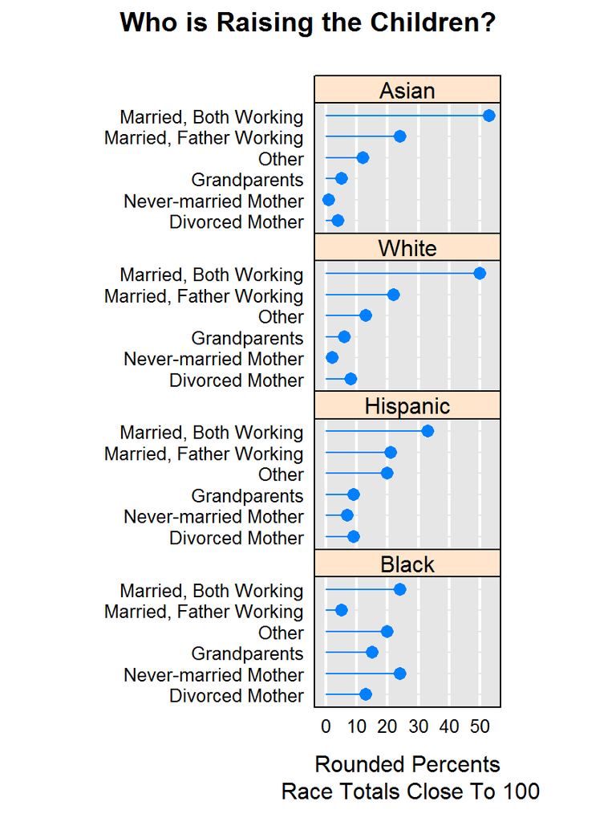

```r
raceOrder <- order(pointsOnLine)
matFixed <- mat[typeOrder,raceOrder]

dotplot(matFixed, groups=FALSE,
  layout=c(1,4),aspect=.7,
  origin=0,type=c("p","h"),
  main="Who is Raising the Children?",
  xlab=xlab,
  scales=list(x=list(tck=0, alternating=FALSE)),
  panel=function(...){
    panel.fill(rgb(.9,.9,.9))
    panel.grid(h=0,v=-1,col="white",lwd=2)
    panel.dotplot(col=rgb(0,.5,1),cex=1.1,...)
  }
)
```

This look simpler than the previous ordering.

4. Race Comparisons for each family type

We transpose the matFixed data matrix from above using t() so rows are races. We change the layout to have 1 column with 6 rows of panels.

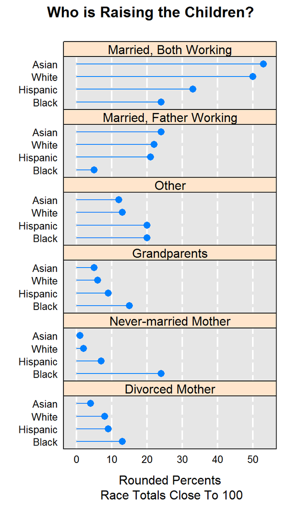

```r
matTranspose <- t( matFixed )

dotplot(matTranspose, groups=FALSE,
  layout=c(1,6), lwd=4,
  origin=0,type=c("p","h"),
  main="Who is Raising the Children?",
  xlab=xlab,
  scales=list(x=list(tck=0, alternating=FALSE)),
  panel=function(...){
    panel.fill(rgb(.9,.9,.9))
    panel.grid(h=0,v=-1,col="white",lwd=2)
    panel.dotplot(col=rgb(0,.5,1),cex=1.1,...)
  }
)
```

The gaps in the grid lines at integer y values are not intended. This seems to be a flaw. We can avoid the flaws using bars.

5. Bar plots

We can produce a barchart by changing the script “dotplot” to “barchart” in both places it occurs, and by commenting out or removing script line that starts with origin = 0 and specifies points and a horizontal line.

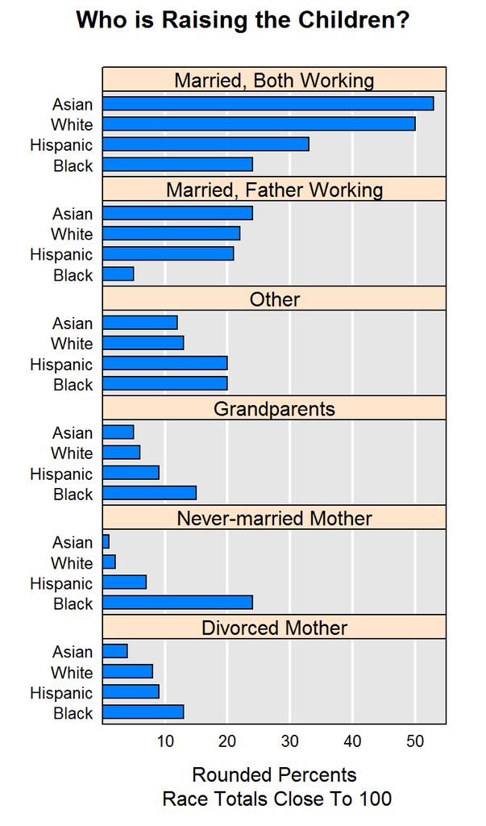

```r
barchart(matTranspose,groups=FALSE,
  layout=c(1,6), xlim=c(0,55),
#  origin=0,type=c("p","h"),
  main="Who is Raising the Children?",
  xlab=xlab,
  scales=list(x=list(tck=0, alternating=FALSE)),
  panel=function(...){
    panel.fill(rgb(.9,.9,.9))
    panel.grid(h=0,v=-1,col="white",lwd=2)
    panel.barchart(col=rgb(0,.5,1),cex=1.1,...)
  }
)
```

6. Adding a reference line for the average percent for each family type

To be correct the percents should be based on the national population. Perhaps this in the paper cited above.

If we had the number of families for each race (and the correct time period) we could compute a population weighted average percent for each family type. We could add this to panels to provide comparisons. We could compute the differences of the race values from the average for each family type and show it explicitly.

Below we obtain Naive averages and show them as red reference lines in the panels. We plot the bars on top of tje reference lines to avoid possibly hiding the end of the bars and indicate in information priority. In layering informmation we normally put the most important information in front (on top).

We should add a legend to explain the red lines, but we won’t do it here.

```r
matTranspose
```

```
##          Divorced Mother Never-married Mother Grandparents Other
## Black                 13                   24           15    20
## Hispanic               9                    7            9    20
## White                  8                    2            6    13
## Asian                  4                    1            5    12
##          Married, Father Working Married, Both Working
## Black                          5                    24
## Hispanic                      21                    33
## White                         22                    50
## Asian                         24                    53
```

```r
typeMean <- colMeans(matTranspose)
typeMean
```

```
##         Divorced Mother    Never-married Mother            Grandparents
##                    8.50                    8.50                    8.75
##                   Other Married, Father Working   Married, Both Working
##                   16.25                   18.00                   40.00
```

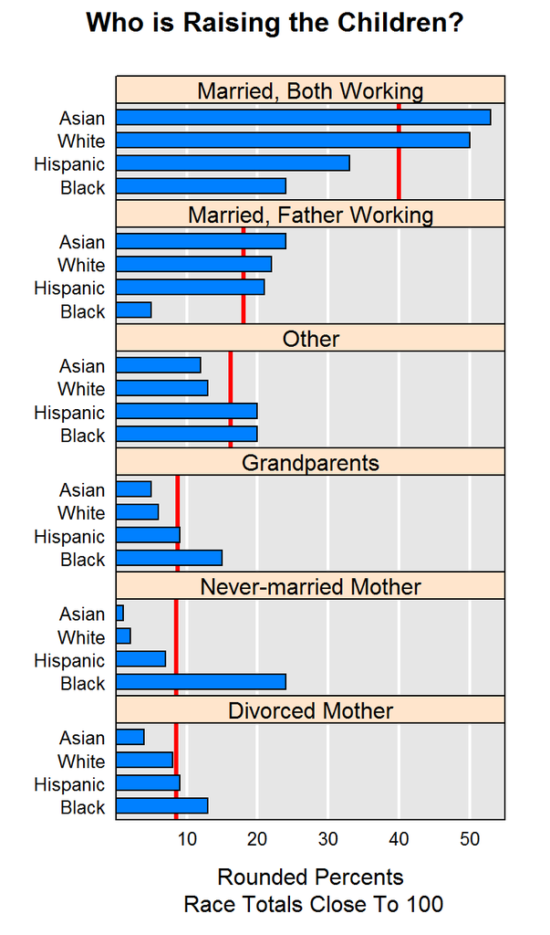

```r
barchart(matTranspose,groups=FALSE,
  layout=c(1,6),xlim=c(0,55),
  main="Who is Raising the Children?",
  xlab=xlab,
  scales=list(x=list(tck=0, alternating=FALSE)),
  typeMean=typeMean,
  panel=function(...){
    panel.fill(rgb(.9,.9,.9))
    panel.grid(h=0,v=-1,col="white",lwd=2)
    i <- panel.number()
    panel.abline(v=typeMean[i],col="red",lwd=3)
    panel.barchart(col=rgb(0,.5,1),cex=1.1,...)
  }
)
```

Side note: I added the vector typeMean as a barchart argument above. In the lattice package this gets passed through to the panel function so abline can find it. The panel number tells which mean in the vector to use.

7. Alternative layouts

The vertical layout is nice from the perspective of having one horizontal scale that serves for all of the panels.

A drawback is that there is a label on the left for every single value.  
The goals of showing less text, space constraints and other considerations may motivate using different layout.

We can try different panel layouts, and change the panel order. It can take some thinking to get the panels ordered in the way we think people will read. People vary so we won’t be right for all people. There are ways to encourage people do read in the intended direction.

7.1 A two column layout

Here I was hoping people would read down the first column and then down the second column when ordering the panels below. Some may read horizontally and the strip labels made foster this.

People might be more inclined to read down if there was a gap between the two columns of panels similar to a two column text layout.

Side note: Observe the use of subscripts to order the columns of the table and the used of panel.number() indices to pick the right element of the typeMean vector.

We may also want to adjust the window size, font size and even alter the text to make the plot look better.

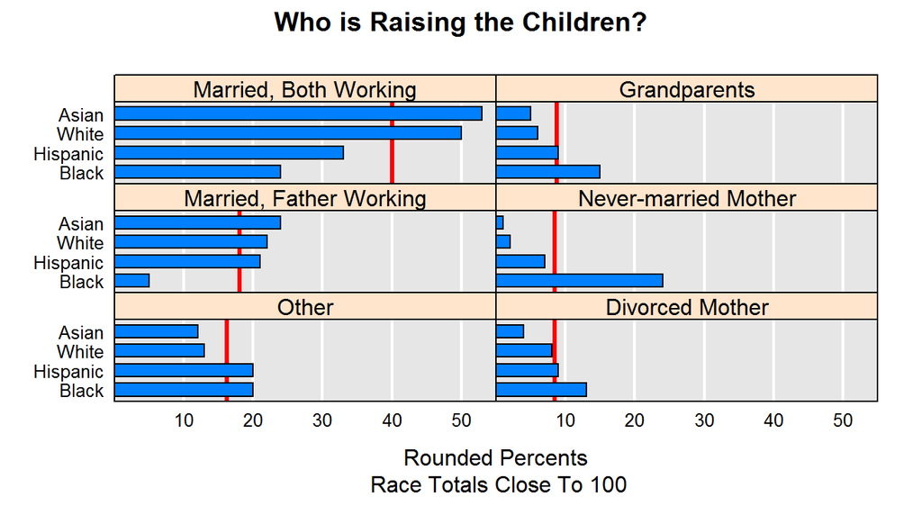

```r
ord <- c(4,1,5,2,6,3)
barchart(matTranspose[,ord], groups=FALSE,
  layout=c(2,3),xlim=c(0,55),
  main="Who is Raising the Children?",
  xlab=xlab,
  scales=list(x=list(tck=0, alternating=FALSE)),
  typeMean=typeMean,
  panel=function(...){
    panel.fill(rgb(.9,.9,.9))
    panel.grid(h=0,v=-1,col="white",lwd=2)
    i <- ord[panel.number()]
    panel.abline(v=typeMean[i],col="red",lwd=3)
    panel.barchart(col=rgb(0,.5,1),cex=.95,...)
  }
)
```

Note that the column of panels on the right has a lot of wasted space.  
There are options in lattice and ggplot to allow the x-axis range to vary and to allow the panel width vary in accordance with the actual x-axis range. This will be addressed in a later class.

7.2 A three column layout

Here the goal is read across the rows. The challenge is to figure out the subscript to put the matrix columns in the desired order and produce the plot.

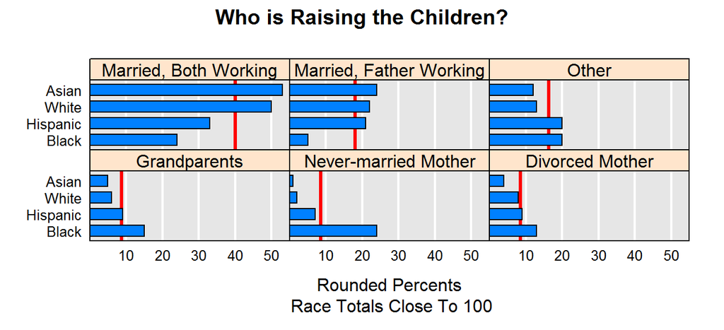

```r
ord <- c(3,2,1,6,5,4)
barchart(matTranspose[,ord],groups=FALSE,
  layout=c(3,2),xlim=c(0,55),
  main="Who is Raising the Children?",
  xlab=xlab,
  scales=list(x=list(tck=0, alternating=FALSE)),
  typeMean= typeMean,
  panel=function(...){
    panel.fill(rgb(.9,.9,.9))
    panel.grid(h=0,v=-1,col="white",lwd=2)
    i <- ord[panel.number()]
    panel.abline(v=typeMean[i],col="red",lwd=3)
    panel.barchart(col=rgb(0,.5,1),cex=.95,...)
  }
)
```

A further step could show deviations from the mean across races using arrows from the mean of race percents to the individaul race percents. This would focus on the range of the data.

8. Using factors in lattice and gglot2 to produce a four column graph analogous to the Washington Post design.

The matrix ordering approach to reorder the plots seem easier to me because use this for many row-labeled plots examples. However many graphics in lattice and ggplot make use of factors, so examples can be helpful.

The script below builds a data.frame called family with three columns: a percent column and two factor columns called type and race. The basic data entry is repeated from above. The script below puts it together differently and incorporates the desired order for levels based on examples above. This is followed by a lattice bar plot and ggplot2 dot plot.

```r
dat<- c(22, 50,  8,  2, 13,  6,
         5, 24, 13, 24, 20, 15,
        21, 33,  9,  7, 20,  9,
        24, 53,  4,  1, 12,  5)


type <- c( "Married, Father Working", "Married, Both Working",
           "Divorced Mother","Never-married Mother",
          "Other", "Grandparents")
race <- c("White","Black","Hispanic","Asian")
rownames(mat) <- type
colnames(mat) <- race
mat
```

```
##                         White Black Hispanic Asian
## Married, Father Working    22     5       21    24
## Married, Both Working      50    24       33    53
## Divorced Mother             8    13        9     4
## Never-married Mother        2    24        7     1
## Other                      13    20       20    12
## Grandparents                6    15        9     5
```

```r
famType <- factor(rep(type,4),levels=type[c(3,4,6,5,1,2)])
race <- factor(rep(race,c(6,6,6,6)),levels=race[c(4,1,3,2)])

family <- data.frame(percent=dat,type=famType,race=race)
family
```

```
##    percent                    type     race
## 1       22 Married, Father Working    White
## 2       50   Married, Both Working    White
## 3        8         Divorced Mother    White
## 4        2    Never-married Mother    White
## 5       13                   Other    White
## 6        6            Grandparents    White
## 7        5 Married, Father Working    Black
## 8       24   Married, Both Working    Black
## 9       13         Divorced Mother    Black
## 10      24    Never-married Mother    Black
## 11      20                   Other    Black
## 12      15            Grandparents    Black
## 13      21 Married, Father Working Hispanic
## 14      33   Married, Both Working Hispanic
## 15       9         Divorced Mother Hispanic
## 16       7    Never-married Mother Hispanic
## 17      20                   Other Hispanic
## 18       9            Grandparents Hispanic
## 19      24 Married, Father Working    Asian
## 20      53   Married, Both Working    Asian
## 21       4         Divorced Mother    Asian
## 22       1    Never-married Mother    Asian
## 23      12                   Other    Asian
## 24       5            Grandparents    Asian
```

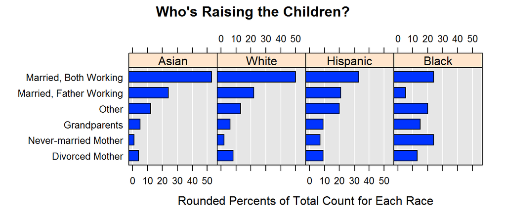

```r
xlab2 <- "Rounded Percents of Total Count for Each Race"

barchart(type~percent | race, layout=c(4,1),data = family,
   main="Who's Raising the Children?",
   xlab = xlab2,
   panel=function(...){
   panel.fill(rgb(.9,.9,.9))
   panel.grid(h=0,v=-1,col="white")
   panel.barchart(col=rgb(0,.2,1),cex=1.1,...)}
)
```

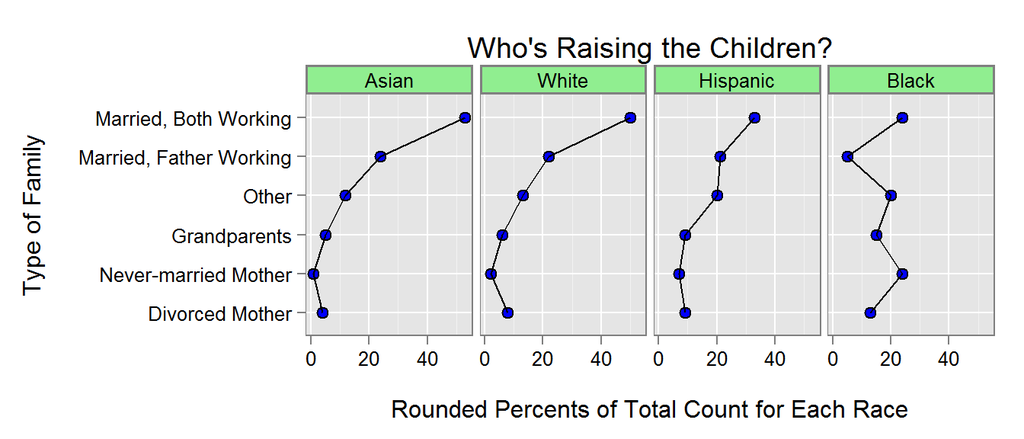

```r
library(ggplot2)

# windows(w=7.5,h=3)

ord <- order(family$type)
familyOrd <- family[ord,]
qplot(x=percent,y=type,facets=. ~ race, group=race,
  fill=I("blue"), shape=I(21), size=I(2.7), data=familyOrd,
  main="Who's Raising the Children?",
  xlab=  paste("\n",xlab2,sep=''),
  ylab ="Type of Family\n") + guides(color=FALSE)+
  geom_path()+
  theme(
    strip.background=element_rect(fill="lightgreen",colour=gray(.5),
      size=1),
    panel.border=element_rect(fill=FALSE,colour=gray(.50)),
    axis.text=element_text(colour="black"))
```

8.1 Some patterns appear

The percent of families with working fathers is similar for Asians and Whites, lower for Hispanics and much lower for Blacks.

The percent with both parents working is consistently higher than the percent with just the father workings. A perhaps partially true way to interpret this is that when a family has a working mother, a working father is more likely to stay with the family.  
A higher percent of black grandparents and never married mothers are raising children than for the other races.

The comparison of two plots above in section 8. is not fair because I did not make the many common elements look the same and did nothing to improve the lattice plot. For example the scale at the top of the lattice plot makes the plot look busy and is easy shift to the other sided of the panel. When it comes to details I want the class to learn the most about ggplot2 so show “improving” a couple of things. Above I show how to put dark gray lines around the facets and how to make tick labels black. We could also make all the tick marks go away and are so motivated since there are grid lines. However I but can’t move the tick labels closer to the faces for better proximity grouping with the grid lines. For the moment I leave the ticks alone even though they are prickly.

I usually prefer dot plots to bar plots.

8.2 Creating two perceptual groups with dots each.

I conjecture that if we connect small group of dots with lines to create perceptual groups of two or three, we could remember the a shape long enough to compare it against another shapes. Comparison would be faster because there would be fewer groups to compare than dots to compare.

When creating factor for our perceptual groups we want the family types for the first three rows to be in one perceptual group. The first three types are “Married, Both Working”, “Married Father Working” and “Other”. We want the other family types to in the second perceptual group and are not concerned about the names for the levels. One way to partition the family types is the use the numeric values of the famType factors.

```r
with(family,levels(famType))
```

```
## [1] "Divorced Mother"         "Never-married Mother"
## [3] "Grandparents"            "Other"
## [5] "Married, Father Working" "Married, Both Working"
```

```r
with(family,as.numeric(famType))
```

```
##  [1] 5 6 1 2 4 3 5 6 1 2 4 3 5 6 1 2 4 3 5 6 1 2 4 3
```

We want “cases” with values 1, 2, and 3 three in one perceptual group and cases with 4, 5 and 6 in the other perceptual group.

We can used cut() to do this with breaks = c(.5, 3.5, 6.5). Values 1, 2 and 3 will be in the interval .5 and 3.5 so belong to first category and be recoded as 1.  
Values 4, 5, and 6 will be in the interval 3.5 to 6.5 so belong in the second category and be recoded as 2.

If we used breaks = c(.5, 2.5, 4.5, 6.5) we could partion the family times into three perceptual groups.

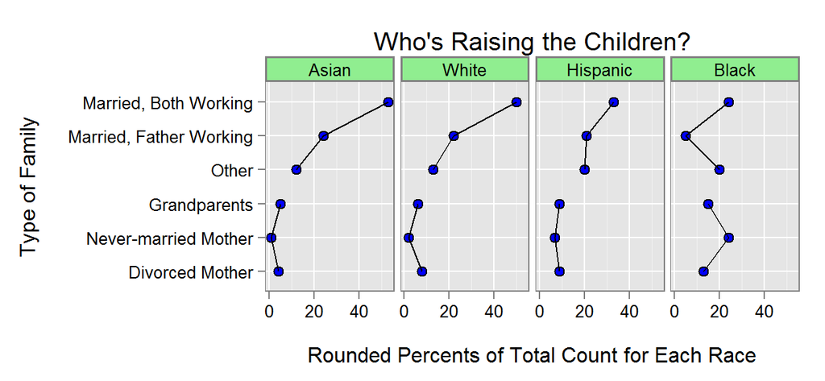

```r
breaks <- c(.5, 3.5, 6.5)
index <- with(family,
  cut(as.numeric(famType),breaks=breaks))
grp <- c("grp1", "grp2")
perGroup <- factor(grp[index],levels=grp)
family$perGroup <- perGroup

# put the cases in family type index order
# to draw paths connect the perceptual groups
ord <- order(family$type)
familyOrd <- family[ord,]

qplot(x=percent,y=type,facets=. ~ race, group=perGroup,
  fill=I("blue"), shape=I(21), size=I(2.7), data=familyOrd,
  main="Who's Raising the Children?",
  xlab=  paste("\n",xlab2,sep=''),
  ylab ="Type of Family\n") + guides(color=FALSE)+
  theme(
    strip.background=element_rect(fill="lightgreen",colour=gray(.5),
      size=1),
    panel.border=element_rect(fill=FALSE,colour=gray(.50)),
    axis.text=element_text(colour="black"))+
  geom_path()
```

We see middle dots stick out in the two black groups of three. The groups have a different shape that the corresponding groups of three for the other races. The Black Married Father Working percent is very low and Black Never-married Mother percent is very high.

Those that get into looking at plots will likely notice many of the same things. Still, to me it seems easier to locate and talk about the groups of three than individual points. Ease of visual identification and verbal description is very important.

We can see that the lower group of three for Hispanics is shifted to the right relative to Asians and Whites. This sentence described nine points. We can more easily compare the slopes for the top two points in top groups of three. I can see the slope between Grandparent and Other is larger for Hispanc even though the line isn’t there. It see easy to focus on points separated by the only gaps.

What do you see? What do people see? So often people do not engage in looking at plots. I conjecture the simple patterns can draw people in to looking more closely.

I talk about slopes. It is true that the constant y separation, is a construction artifact that influences our preception of and the calculation slopes. Nonetheless the ordering of slopes is still meaningful and addresses comparing pair of factors to each other.

See the Carr and Sun newsletter article in the folder for a more complex example. That example accommodates 10 points (10 factor levels) by connecting dots in three groups using a 3-4-3 pattern. I think the middle group of four works moderately well for comparison purposes. I suspect comparison is more much difficult with groups of five but manageable when the middle dot is distinguished from the rest by say color. Then it creates smaller perceptual groups. I conjecture that the comparison difficulty increases rapidly as the number of dots connected by a line exceeds five.

A substantial portion of people do not want to connect dots.  
Some insist that this implies interpolation. Myself, I don’t know how to interpolate between the classes of Grandparents and Other. I think the issue is more the lack of familiarity with perceptual grouping examples. There may well be a lack cognitive research demonstrating confirming or denying my conjecture efficiency. I need to search the literature.

Of course when people disagree it is natural to think they would agree with us if they just understood. Fairly often dissagreements remain even when those disaggreeing are very smart and have considered the arguments.

8.3 Appearance comments

This lattice dot representation with a line to zero is not standard but reasonable. However, it may not be obvious that the center of dot represents the value. This could be addressed by plotting a little white dot on top of each blue dot.

As indicated in the newsletter article each strip label seem to dominate the body of it’s panels The color areas in a bar plot have “visual” weight and can hold there own again the strip labels. This is good in calling attending the statistics. Still, for me bars get too much area. Little bars can be just as important as big bars but are easy to overlook.  
Bars hide high grid lines and iterrupt the visual flow when scanning across them except the sorted provide a nice monotonic sequence.

It is harder for me to imagine connecting centers of bar ends to other centers fo bars. The edges get in way of my lines.

I can see around dots like water flowing around rocks. At the same time connecting lines are easy to imagine. I can see them easier that the W in the stars, and seeing Cassiopeia’s chair is pretty easy to see once I’m be pointed in the right direction. Imagination takes a bit of work. Showing the lines offloads the work and we can know we are seeing the same lines as other people.  
We can use the saved energy to think about what the pattern means. With lines present the pattern won’t go away while we are thinking.

8.4 Creating three groups of two

Modify the cut() function in 8.2 to produce three groups of size 2. Add this new grouping factor to the family data.frame. Follow the 8.2 example to order this data.frame in family type order and adapt the qplot script as necessary to use this new data frame and its aesthesics to produce the plot.

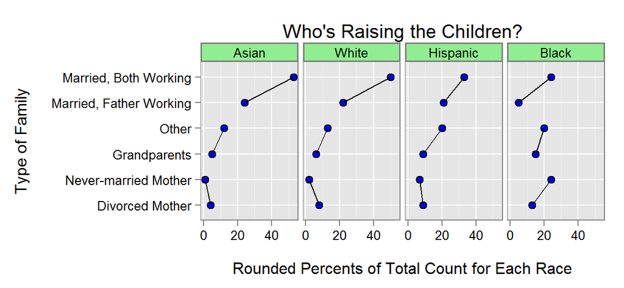

```r
breaks <- c(.5, 2.5, 4.5, 6.5)
index <- with(family,
  cut(as.numeric(famType),breaks=breaks))
grp <- c("grp1", "grp2", "grp3")
perGroup <- factor(grp[index],levels=grp)
family$perGroup <- perGroup

# put the cases in family type index order
# to draw paths connect the perceptual groups
ord <- order(family$type)
familyOrd <- family[ord,]

qplot(x=percent,y=type,facets=. ~ race, group=perGroup,
  fill=I("blue"), shape=I(21), size=I(2.7), data=familyOrd,
  main="Who's Raising the Children?",
  xlab=  paste("\n",xlab2,sep=''),
  ylab ="Type of Family\n") + guides(color=FALSE)+
  theme(
    strip.background=element_rect(fill="lightgreen",colour=gray(.5),
      size=1),
    panel.border=element_rect(fill=FALSE,colour=gray(.50)),
    axis.text=element_text(colour="black"))+
  geom_path()
```